# Anna, was ist eigentlich dieses DTW?

31. Juli 2017

## 'Recap' Zeitreihen

- Zeitreihen sind Diskrete Samplings von diskreten oder kontinuierlichen Funktionen, z. B.
  - Bewegungsdaten (Mocap)
  - Video Aufnahmen
  - EKG, EMG etc.
  - Audio: Musik, Sprache, Geräusche
  - Aktienkurse

## Beispiel EKG

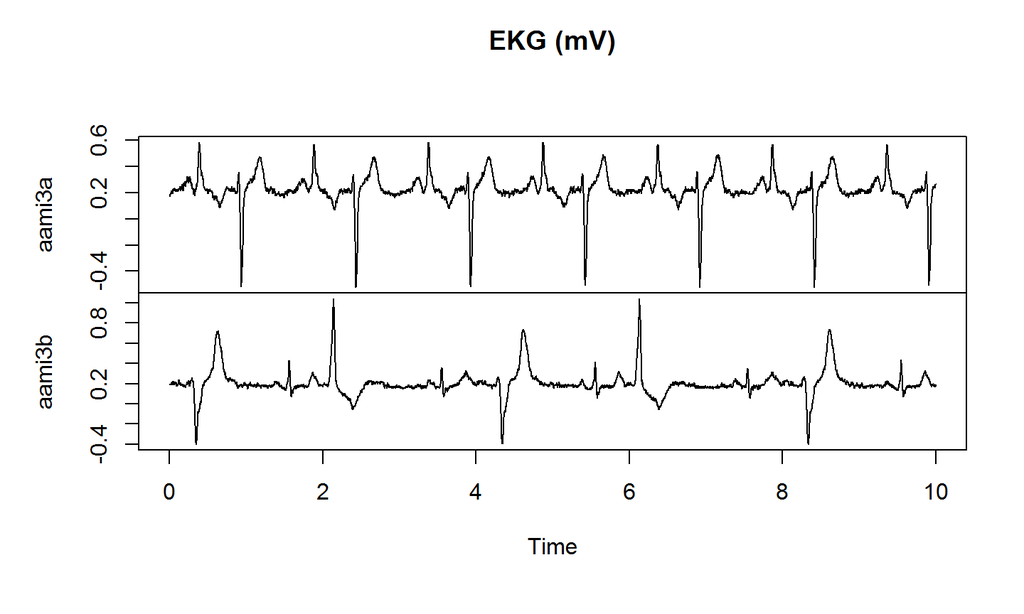

## Darstellung von Zeitreihen

- Zeitlich geordnete Abfolgen von Zuständen (Posen/Frames)

\[x = \left(x_1,\ldots,x_n\right) \space n\in \mathbb{Z}_+\]

- Zu einer Zeitreihen gehören
  - ihre Frame Rate und ihre Sampling Rate
  - (meistens) ihre Einheit, z. B. Zentimeter, Millivolt

## Zeitreihen vergleichen

- Vergleiche zwischen Zeitreihen werden zu vielerlei Zwecken angestellt. Dazu gehören unter anderem
  - Spracherkennung
  - Bewegungserkennung
  - Clustering/Gruppierung von ähnlichen Signalen
  - Klassifizierung von Verhalten
- Dabei ergeben sich typischwerweise Fragen wie:
  - Welche Distanz- bzw. Ähnlichkeitsbegriffe kann man überhaupt verwenden?
  - Was ist wenn die Zeitreihen verschieden lang sind?
  - Was ist mit phasenverschobenen Signalen?

## Dynamic Time Warping zum Vergleich von Zeitreihen

- Der DTW Algorithmus berechnet die Veränderung der Zeitachse der Query, die nötig wäre, um optimal auf die Referenz abzubilden
- Das Ergebnis ist die kumulative Distanz nach der Optimierung sowie die 'warping function', die die genaue Korrespondenz zwischen Query und Referenz angibt

## [So geht's im Schnelldurchlauf:](https://www.youtube.com/watch?v=tqL8Zjz7oJo)

## Lokale Distanzmaße

- Beispiel: MoCap Daten: Posen in 3-D werden durch Quaternionen dargestellt. Optimierungsproblem: Rotation* von einer Pose auf die andere
- Müssen nicht Euklidisch sein
- Müssen nicht mal eine Metrik sein

*Für ein gegebenes Quaternion \(q = [s,(x,y,z)]\in\mathbb{H}\) laßt sich folgende Rotationsmatrix herleiten:   \[ \left(\begin{matrix}1−2(y^2 +z^2), 2(xy−sz), 2(xz+sy)\\ 2(xy+sz), 1−2(x^2 +z^2), 2(yz−sx)\\ 2(xz−sy), 2(yz+sx), 1−2(x^2 +y^2 )\end{matrix}\right)\] ]

## Vergleich von Signalen Durch DTW

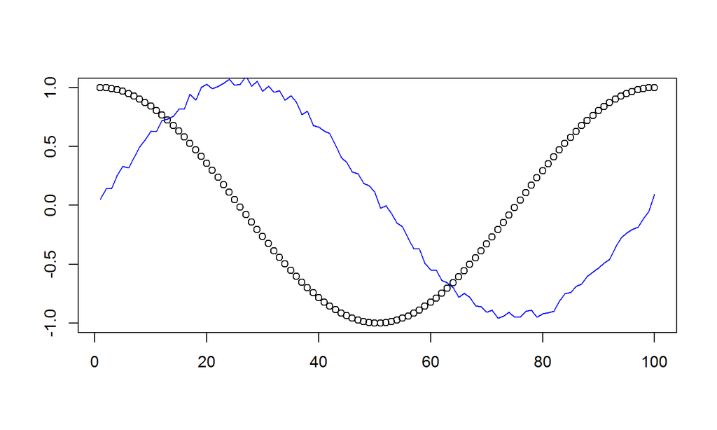

## Alignment durch einen sogenannten Warping Pfad

- Phasenverschiebung im 'flachen' Start der Kurve sichtbar
- Das Rauschen in der Query ist auch im Alignment zu sehen

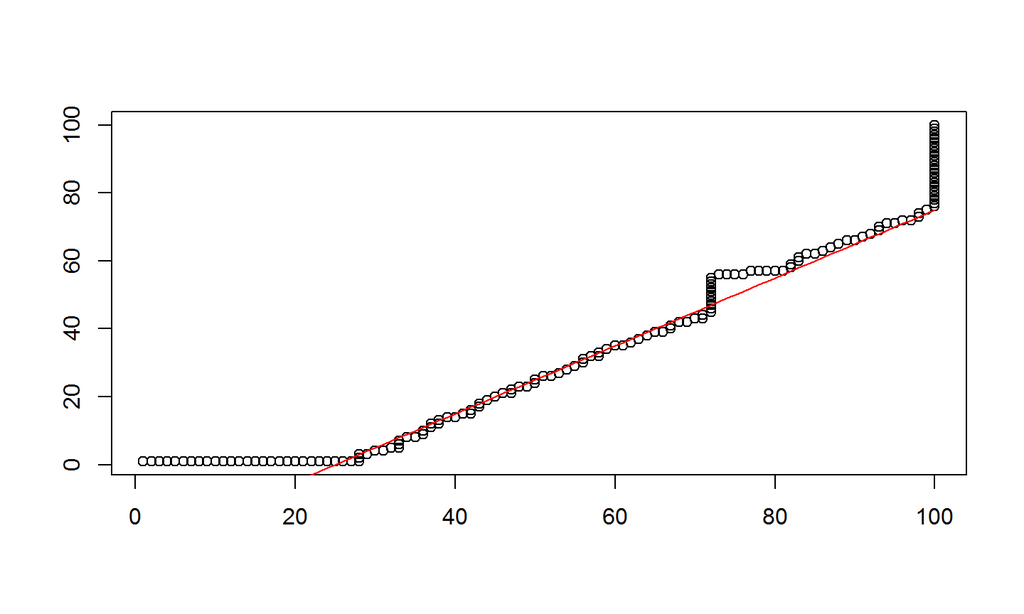

## Wie ging das jetzt?

\[ Q = \left(1,3,1,2,1,1,1\right) \] \[ R = \left(1,1,3,1,2,1,1\right) \]

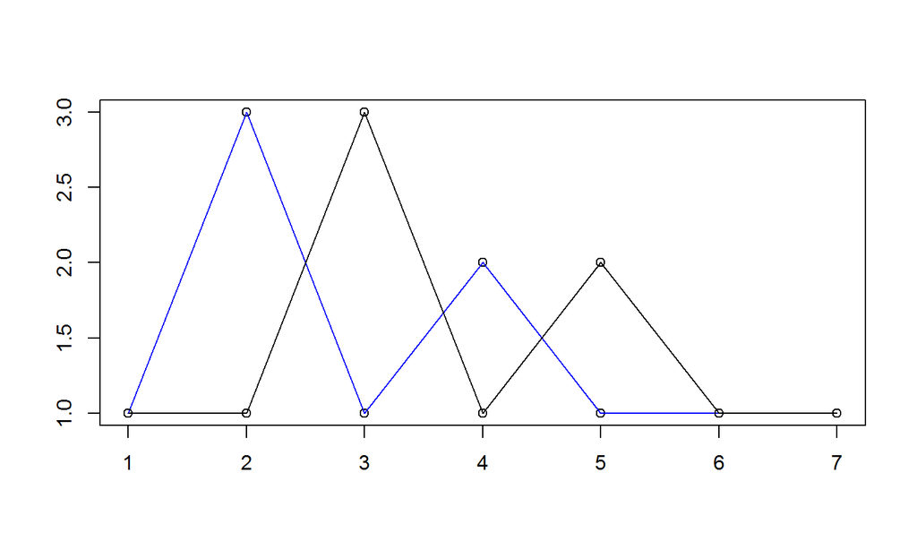

## Lasst uns das eben gemeinsam machen!

```
##      [,1] [,2] [,3] [,4] [,5] [,6] [,7]
## [1,]    0    8    0    3    0    0    0
## [2,]    0    8    0    3    0    0    0
## [3,]    3    5    3    0    3    3    3
## [4,]    0    8    0    3    0    0    0
## [5,]    8    0    8    5    8    8    8
## [6,]    0    8    0    3    0    0    0
## [7,]    0    8    0    3    0    0    0
```

## Kostenmatrix als Terrain

Rot: Warping Pfad

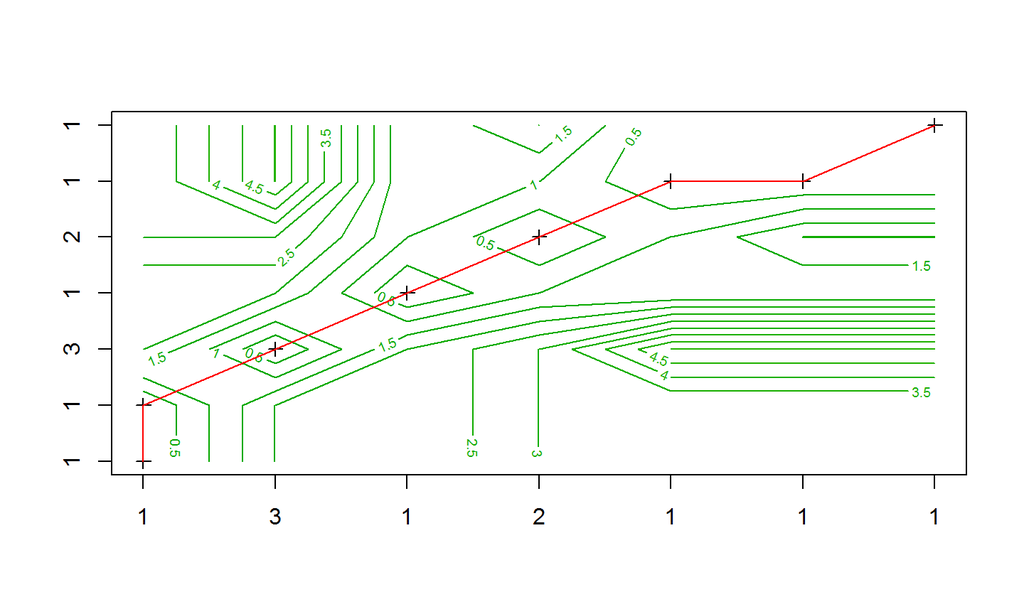

## Kostenmatrix für das Kosinus-Beispiel

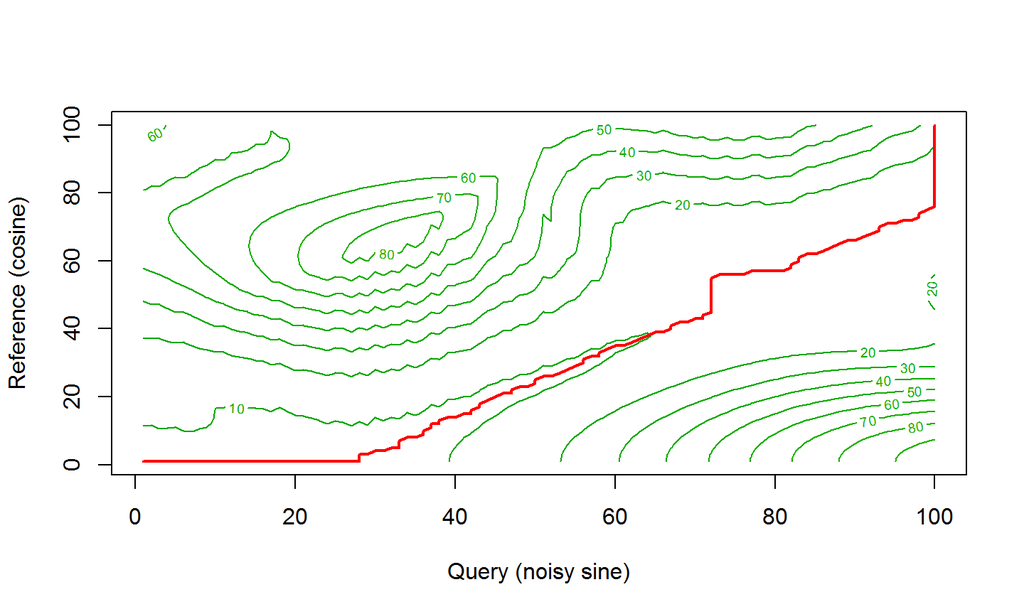

## Partielles Alignment

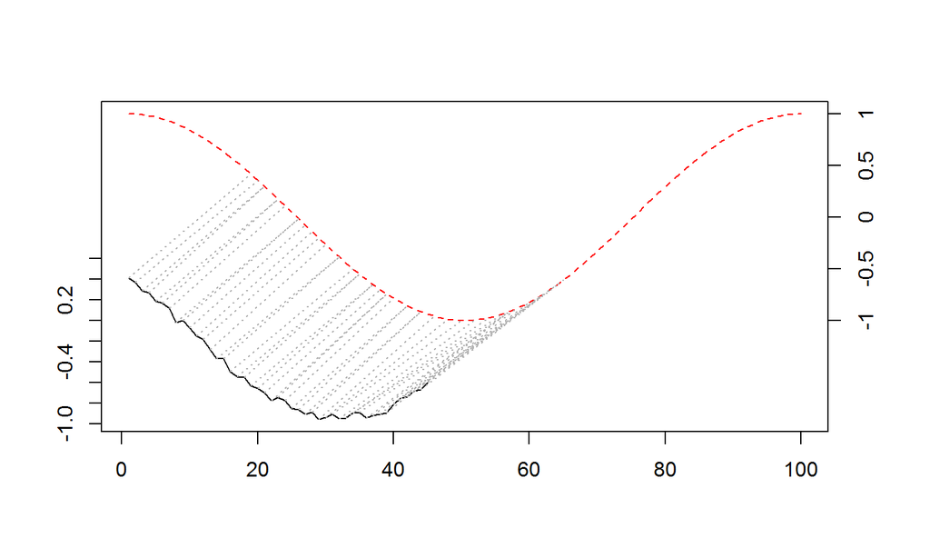

## Zwei Arten der Darstellung: Gewarpte Query…

- Blau: gewarpte Query

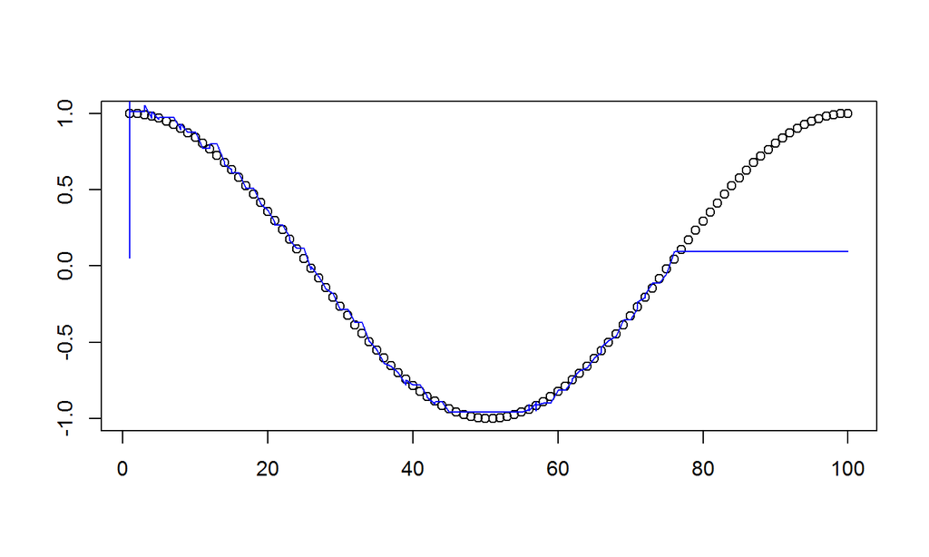

## … Oder invers gewarpte Referenz

-Schwarz: invers gewarpte Referenz

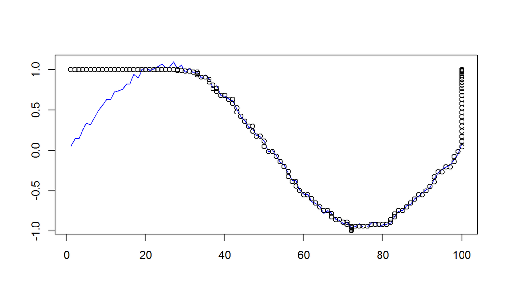

## Weiteres Beispiel

- 2 x Kosinus vs Kosinus

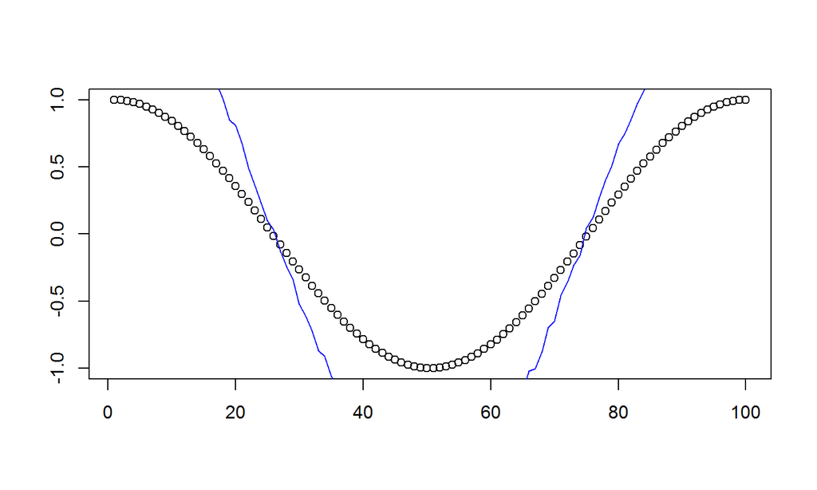

## Alignment dazu

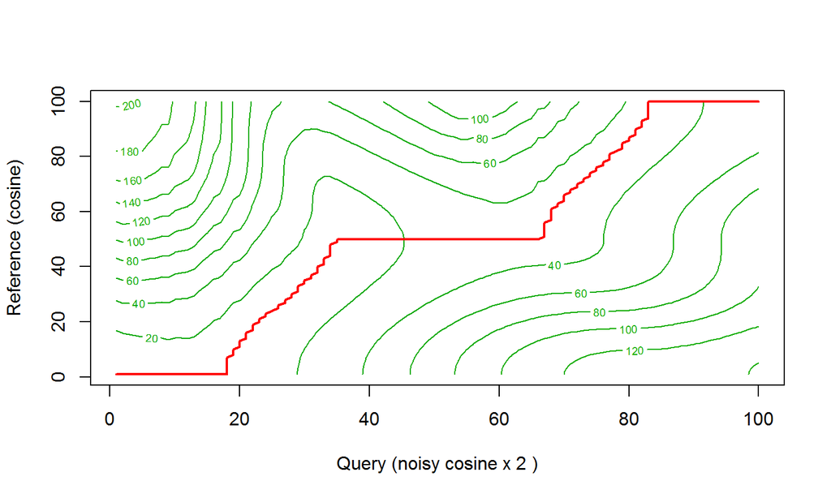

## Zusammenfassung und Fragen

- DTW nimmt sich zwei Zeitreihen und vergleicht sie 'Punkt für Punkt', obtimiert sie dann aber global bzw. abschnittsweise (partielles Alignment)
- DTW muss ein lokales Distanzmaß berücksichtigen, welches wir in der Praxis geeignet wählen dürfen
- Wie sieht also z. B. ein User Flow als Zeitreihe aus?
- Wie kann man Distanzen auf User Flows definieren?

## Ideenskizze

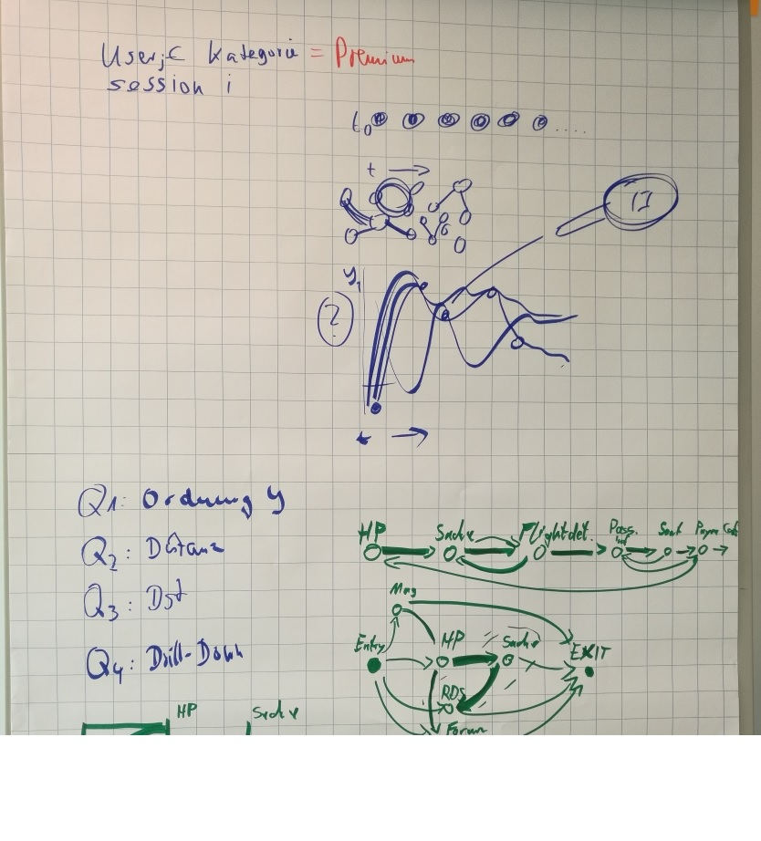

## Frequentistischer Ansatz

- Beispieldaten:

  SELECT count(*) as count, first_content, second_content FROM( SELECT lead(content_id,1) OVER (PARTITION BY session_id ORDER BY date_time) as second_content, content_id as first_content FROM webtrekk.request WHERE split(content_id,'[.]')[1] in ('web','mew','amp','mweb') and dt LIKE '2017-06-%%') as x GROUP BY first_content, second_content ORDER BY count desc

## Übergangswahrscheinlichkeiten

(Auszug)

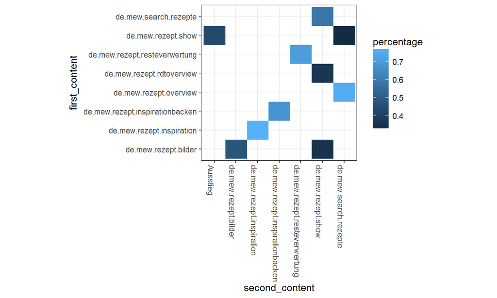

## Darstellung as Graph

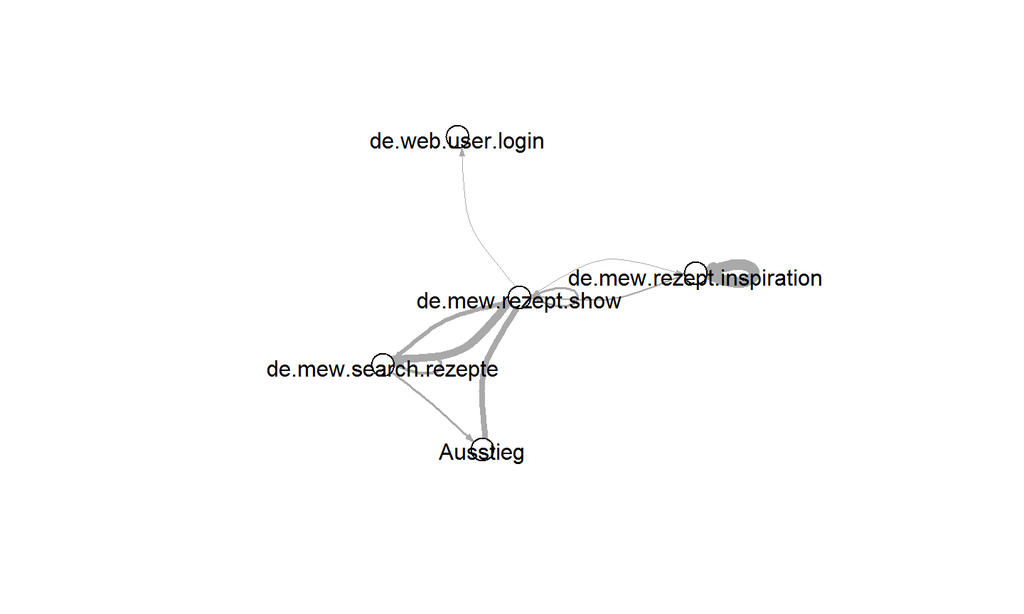

## Praktisches Beispiel

\[Q=\left(I, S, S.R, S.R, R, S.R, R, S.R, R\right)\] \[R=\left(I, S.R, R, S.R, R, S.R, S.R, R, R\right)\] I = mew.index  
S.R = mew.search.rezepte  
R = mew.rezept.show

- Lokale Distanzen \(d(I,R) = ?\)
  - Probabilistischer Ansatz:  
    \(d(I,R)=\) Häufigkeit dieser Paarung/Häufigkeit aller Paarungen -Achtung: hier suchen wir zunächst den Pfad mit den höchsten Kosten

```
##       X2   X3   X4   X5   X6   X7   X8   X9
## 2  0.004 0.32 0.32 0.19 0.32 0.19 0.32 0.19
## 3  0.004 0.32 0.32 0.19 0.32 0.19 0.32 0.19
## 4  0.005 0.22 0.22 0.58 0.22 0.58 0.22 0.58
## 5  0.005 0.22 0.22 0.58 0.22 0.58 0.22 0.58
## 6  0.004 0.32 0.32 0.19 0.32 0.19 0.32 0.19
## 7  0.005 0.22 0.22 0.58 0.22 0.58 0.22 0.58
## 8  0.004 0.32 0.32 0.19 0.32 0.19 0.32 0.19
## 9  0.005 0.22 0.22 0.58 0.22 0.58 0.22 0.58
## 10 0.003  0.6  0.6 0.06  0.6 0.06  0.6 0.06
```

## Kostenmatrix hierfür

mit geschätztem Warping Pfad (rot)

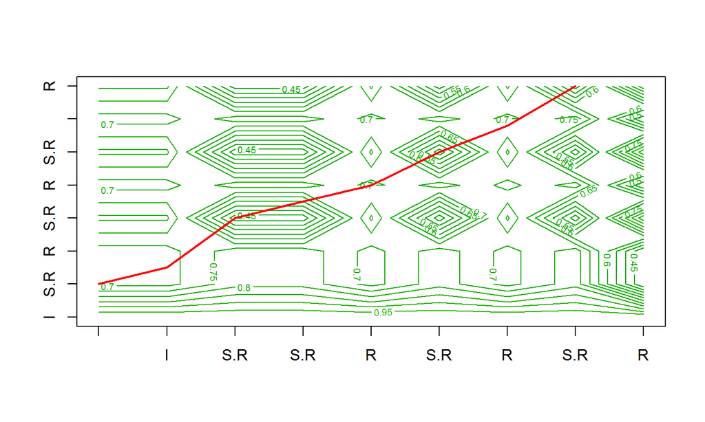